# Aplicando PCA em dados de parlamentares

### Contexto

PCA é um procedimento matemático que utiliza uma transformação ortogonal (ortogonalização de vetores) para converter um conjunto de observações de variáveis possivelmente correlacionadas num conjunto de valores de variáveis linearmente não correlacionadas chamadas de componentes principais.

Em outras palavras, PCA é uma tentativa de reduzir muitas dimensões a um conjunto menor de dimensões principais.

Nosso **objetivo** é aplicar PCA aos dados de deputados que envolvem domínios diversos como atuação na câmara em proposições de Meio Ambiente, aderência ao governo em votações de Meio Ambiente, posições em votações importantes da legislatura passada, vínculo com o agronegócio, dentre outras.

### Sobre os dados

As variáveis selecionadas foram: - **total_declarado:** Total declarado pelo deputado ao TSE nas eleições de 2018 em bens relacionados a Agricultura e Pecuária. Ex: imóveis rurais, fazendas, cabeças de gado, etc. - **numero_empresas_associadas:** Número de empresas nas quais o deputado é sócio. Dados obtidos da Receita Federal por meio do Brasil.IO em Agosto de 2019. - **proporcao_doacoes_agro:** razão entre o total doado por empresas relacionadas a Agricultura (pelo CNAE) e o total doado para o parlamentar durante as eleições de 2018. - **Aderência ao Governo em votações de Meio Ambiente:** indicador da proporção do número de votações em que seguiu a orientação do Governo em votações de Meio Ambiente. Valor entre 0 e 1, mas também pode ser indefinido quando não há votações suficientes para o cálculo da aderência. - **Investimento recebido pelo Partido:** indicador do nível de investimento do partido no deputado durante as eleições de 2018. Valor entre 0 e 1 que é melhor explicado neste [relatório](https://analytics-ufcg.github.io/vozativa-dados/investimento-partidos). - **Número de frentes relacionadas ao Meio Ambiente:** quantidade de frentes relacionadas ao Meio Ambiente que o deputado faz parte. - **Atuação em proposições de Meio Ambiente:** número de documentos que o deputado foi autor relacionadas ao tema de Meio Ambiente.

A seguir iremos analisar essas variáveis e como se correlacionam.

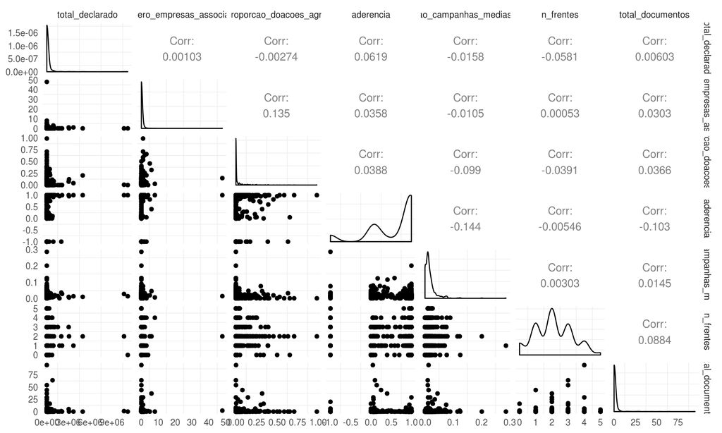

Não existe uma correlação forte entre as variáveis, contudo pela distribuição das mesmas é possível perceber o quanto são enviesadas a direita, observada uma cauda bem longa. Isso evidencia a presença de poucos valores bastante altos na escala de cada variável, enquanto que a maior parte dos dados se concentra numa faixa menor em relação a esses valores mais raros.

Para remediar esse problema podemos usar a escala de log nos dados que irá considerar a magnitude de grandeza dos valores e não os valores absolutos em si.

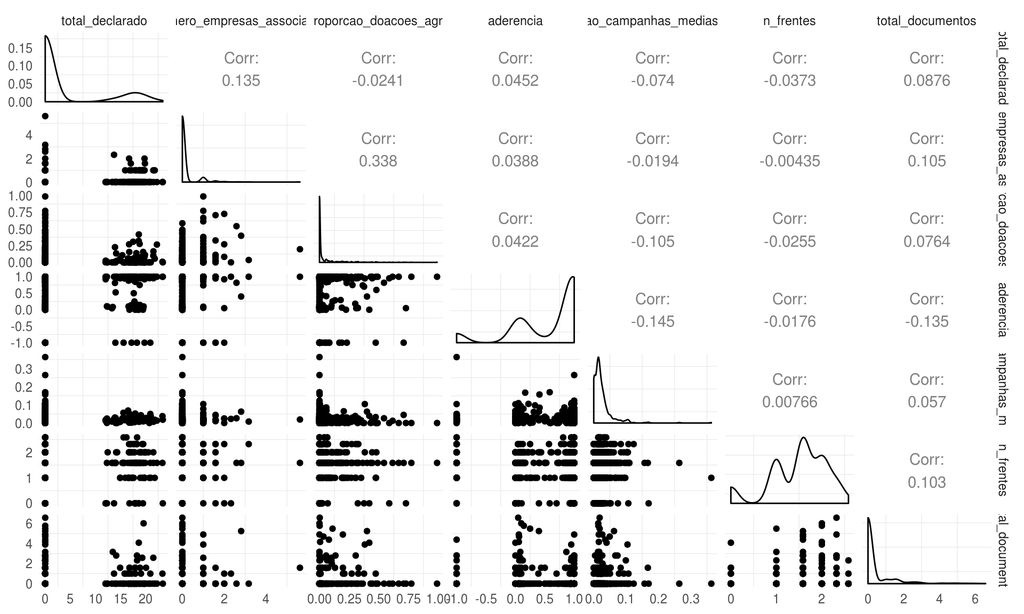

É possível perceber para a variável do total declarado em bens rurais que houve um mudança na distribuição. Como esperado a escala de log espalha as observações de forma que é possível observar os pontos de forma mais clara e com o objetivo de entender as grandes diferenças entre as variáveis mas também as pequenas diferenças. Nota-se ainda a presença de muitos valores iguais a 0 nessa variável.

Com o objetivo de normalizar as variáveis de forma que cada uma tenha o mesmo “poder” de influência no cálculo das dimensões via PCA todas elas foram colocadas numa mesma escala.

Aplicamos o PCA aos dados e obtivemos dimensões que são resultado da combinação linear das variáveis escolhidas.

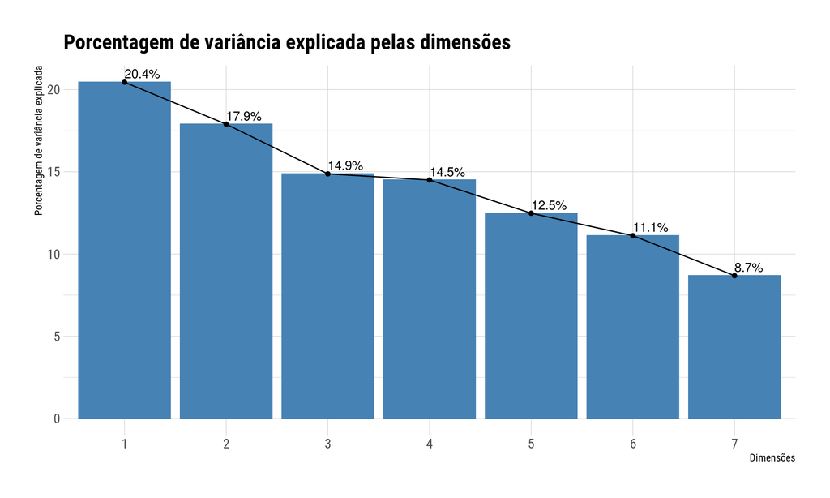

Cada dimensão obtida consegue representar uma porcentagem da variância nos dados, em outras palavras, cada dimensão consegue explicar parte dos dados.

Cada dimensão pode ser influenciada por um grupo de variáveis distintas e essas dimensões podem ser usadas para explicar a variância nos dados dessas variáveis.

A seguir apresentamos quais variáveis mais influenciaram as dimensões geradas via PCA.

| Variável | Dim1 | Dim2 | Dim3 | Dim4 | Dim5 | Dim6 | Dim7 |
| --- | --- | --- | --- | --- | --- | --- | --- |
| total_declarado | 7.56219723034578 | 0.0510521756837516 | 62.3697251935735 | 10.1827993951093 | 2.00051780103227 | 7.31150407282239 | 10.522204131433 |
| numero_empresas_associadas | 41.5527439384592 | 1.33077428515061 | 1.69320276590423 | 1.10101855332685 | 7.50576053638876 | 5.61652259930388 | 41.1999773214664 |
| proporcao_doacoes_agro | 36.9073749466066 | 0.0136713053197599 | 19.2768305568806 | 0.360294106050486 | 1.14496856456539 | 0.014930463332996 | 42.2819300572442 |
| aderencia | 2.42312815510117 | 34.2046607027476 | 1.25463660984477 | 6.04667598825231 | 27.4172743118919 | 28.6333629623084 | 0.0202612698537372 |
| proporcao_campanhas_medias_receita | 6.0111296879334 | 21.8965867957788 | 5.06975208562225 | 10.1691239208327 | 51.665525354439 | 0.452812668966197 | 4.73506948642767 |
| n_frentes | 0.043128086418997 | 8.57972006088409 | 2.82270091658864 | 71.4119248207052 | 5.56059663984631 | 10.906769121858 | 0.675160353698741 |
| total_documentos | 5.50029795513477 | 33.9235346744354 | 7.51315187158602 | 0.728163215723163 | 4.70535679183631 | 47.0640981114081 | 0.565397379876259 |

A seguir apresentamos como os deputados estão distribuídos considerando essas as duas dimensões que melhor explicam os dados.

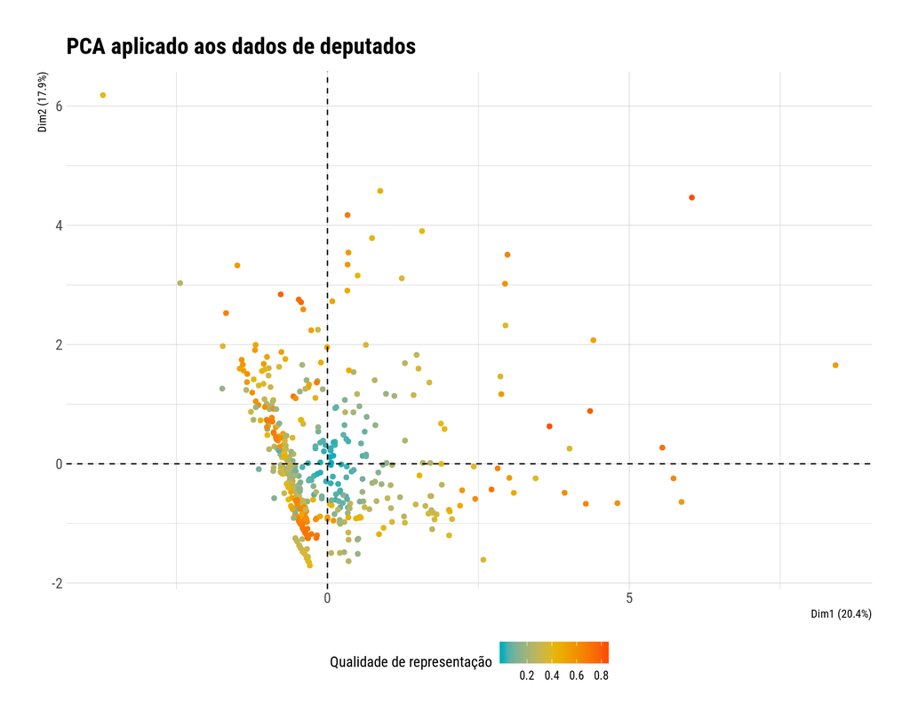

Deputados que estão próximos no gráfico são parecidos em relação as variáveis iniciais escolhidas. A cor do deputado indica a qualidade de representação das dimensões com relação as variáveis originais.

As variáveis originais tiveram suas dimensões reduzidas a duas, no entanto podemos observar como essas variáveis influenciam as dimensões obtidas via PCA.

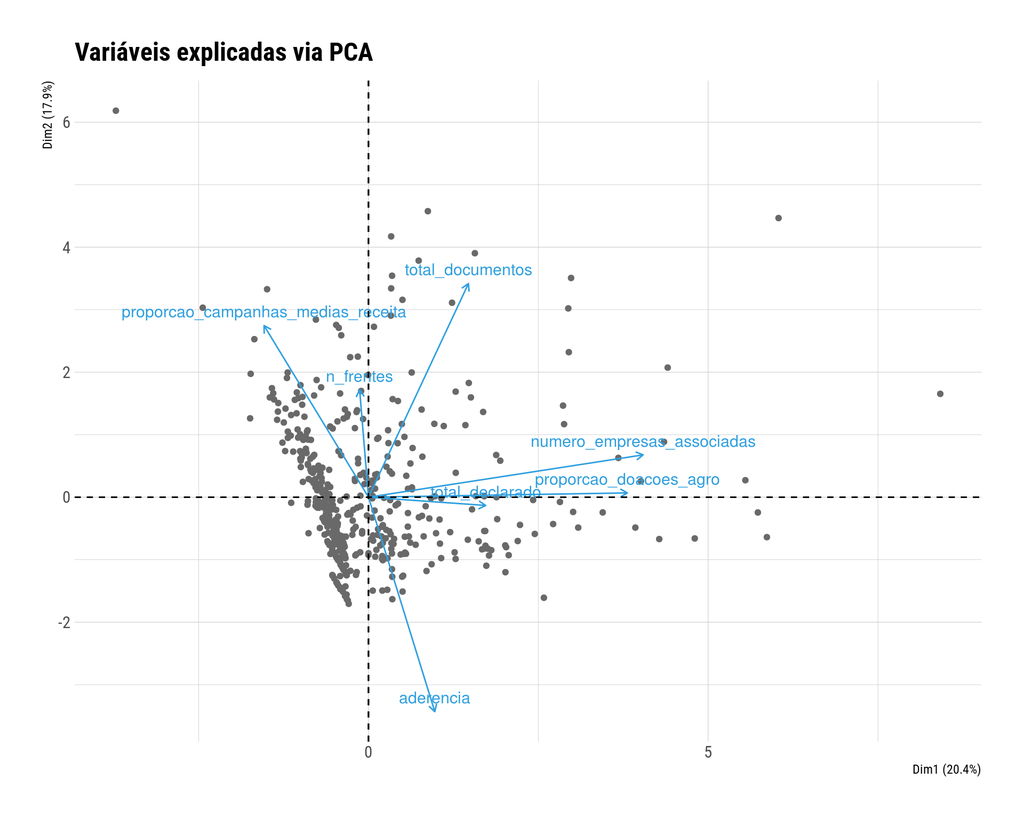

É possível perceber que vetores ligados ao vínculo com o Agronegócio possuem direções parecidas.

A direção dos vetores indica o sentido de crescimento das variáveis quando explicadas pelas dimensões obtidas via PCA.

Abaixo iremos identificar quais os deputados representados na visualização

[interactive chart not shown]